# FInal Proejct DS 686 Q(A-G)

# Q#C

#create a data frame

```r
# Load necessary libraries
library(ggplot2)
library(dplyr)

# Create the data frame with consistent row numbers
ship_data <- data.frame(
  Ship_Type = factor(rep(c('A', 'B', 'C', 'D', 'E'), each = 8)),
  Year_of_Construction = factor(rep(rep(c('1960-64', '1965-69', '1970-74', '1975-79'), each = 2), times = 5)),
  Period_of_Operation = factor(rep(c('1960-74', '1975-79'), times = 20)),
  Months_of_Service = c(
    127, 63, 1095, 1095, 1512, 3353,0, 2244, 44882, 17176, 28609, 20370, 7064, 13099, 0, 7117, 1179, 552,  781,676, 783, 1948, 0, 274, 251, 105, 288, 192,349, 1208, 0, 2051, 45,0,789,437,1157,2161,0,542 ),
  Damage_Incidents = c(
    0, 0, 3, 3, 12, 11, 39, 29, 58, 15, 2, 14, 42, 8, 18, 21, 3, 1, 0, 12,
    0, 1, 0, 0, 0, 0, 2, 11, 4, 0, 0, 7, 5, 12, 0, 1, 0, 0, 3, 3
  )
)

# View the data
print(ship_data)
```

```
##    Ship_Type Year_of_Construction Period_of_Operation Months_of_Service
## 1          A              1960-64             1960-74               127
## 2          A              1960-64             1975-79                63
## 3          A              1965-69             1960-74              1095
## 4          A              1965-69             1975-79              1095
## 5          A              1970-74             1960-74              1512
## 6          A              1970-74             1975-79              3353
## 7          A              1975-79             1960-74                 0
## 8          A              1975-79             1975-79              2244
## 9          B              1960-64             1960-74             44882
## 10         B              1960-64             1975-79             17176
## 11         B              1965-69             1960-74             28609
## 12         B              1965-69             1975-79             20370
## 13         B              1970-74             1960-74              7064
## 14         B              1970-74             1975-79             13099
```

[output cut: 67 more lines]

#Plot the observed rate of damage incidence over the number of covariate classes.

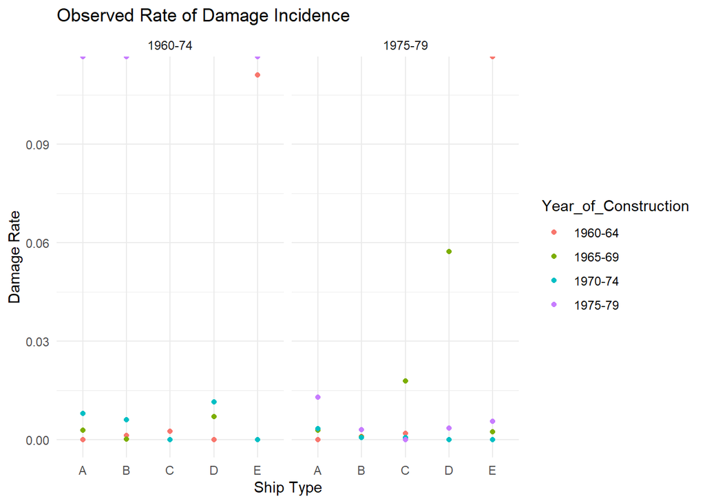

```r
# Plot the observed rate of damage incidence
ggplot(ship_data, aes(x = Ship_Type, y = Damage_Incidents / Months_of_Service, color = Year_of_Construction)) +
  geom_point() +
  facet_wrap(~ Period_of_Operation) +
  labs(title = "Observed Rate of Damage Incidence",
       x = "Ship Type",
       y = "Damage Rate") +
  theme_minimal()
```

```r
# Fit the Poisson regression model with Months_of_Service as an offset term
# Fit the Poisson regression model with Months_of_Service as an offset term
library(VGAM)
# Ensure there are no NA values in the Damage_Incidents column
ship_data <- ship_data %>%
  filter(!is.na(Damage_Incidents))

# Ensure there are no zeros in the Months_of_Service column
ship_data <- ship_data %>%
  filter(Months_of_Service > 0)

# Fit the Poisson regression model
m.pois <- glm(Damage_Incidents ~ Ship_Type + Year_of_Construction + Period_of_Operation + offset(log(Months_of_Service)),
              family = poisson, data = ship_data)

# Print the summary of the model
summary(m.pois)
```

```
##
## Call:
## glm(formula = Damage_Incidents ~ Ship_Type + Year_of_Construction +
##     Period_of_Operation + offset(log(Months_of_Service)), family = poisson,
##     data = ship_data)
##
## Coefficients:
##                             Estimate Std. Error z value Pr(>|z|)
## (Intercept)                  -5.2288     0.2065 -25.326  < 2e-16 ***
## Ship_TypeB                   -1.3817     0.1766  -7.823 5.17e-15 ***
## Ship_TypeC                   -0.5918     0.2815  -2.102  0.03556 *
## Ship_TypeD                   -0.3088     0.2465  -1.253  0.21033
## Ship_TypeE                   -1.1650     0.3601  -3.235  0.00122 **
## Year_of_Construction1965-69  -0.4153     0.1844  -2.252  0.02429 *
## Year_of_Construction1970-74   0.3473     0.1870   1.857  0.06332 .
## Year_of_Construction1975-79   1.0929     0.2317   4.717 2.40e-06 ***
## Period_of_Operation1975-79   -0.4453     0.1533  -2.905  0.00368 **
## ---
## Signif. codes:  0 '***' 0.001 '**' 0.01 '*' 0.05 '.' 0.1 ' ' 1
##
## (Dispersion parameter for poisson family taken to be 1)
##
##     Null deviance: 430.60  on 33  degrees of freedom
## Residual deviance: 269.94  on 25  degrees of freedom
## AIC: 373.43
##
## Number of Fisher Scoring iterations: 8
```

```r
# Exponentiate the coefficients to get the relative risks
#estimated risk ratios
exp_coef <- exp(coef(m.pois))
print(exp_coef)
```

```
##                 (Intercept)                  Ship_TypeB
##                 0.005359969                 0.251148752
##                  Ship_TypeC                  Ship_TypeD
##                 0.553340274                 0.734297111
##                  Ship_TypeE Year_of_Construction1965-69
##                 0.311931082                 0.660134077
## Year_of_Construction1970-74 Year_of_Construction1975-79
##                 1.415250010                 2.982907352
##  Period_of_Operation1975-79
##                 0.640602547
```

```r
# Calculate the Wald confidence intervals for the relative risks
exp(confint.default(m.pois))
```

```
##                                   2.5 %      97.5 %
## (Intercept)                 0.003576216 0.008033426
## Ship_TypeB                  0.177658179 0.355039640
## Ship_TypeC                  0.318673268 0.960813125
## Ship_TypeD                  0.452908781 1.190509592
## Ship_TypeE                  0.154011048 0.631779351
## Year_of_Construction1965-69 0.459925030 0.947495726
## Year_of_Construction1970-74 0.980921938 2.041887854
## Year_of_Construction1975-79 1.894123484 4.697548150
## Period_of_Operation1975-79  0.474323376 0.865172673
```

Period of Operation: Ships operating in 1975-79 have a damage incident rate that is about 0.64 times the rate for the reference category (1960-74), holding all other variables constant. This is statistically significant as the 95% confidence interval (0.47, 0.87) does not include 1.

In summary, the ship type, year of construction, and period of operation all have significant effects on the rate of damage incidents, according to this model.

```r
# Poisson regression model with an offset
# Model fit statis
anova(m.pois)
```

```
## Analysis of Deviance Table
##
## Model: poisson, link: log
##
## Response: Damage_Incidents
##
## Terms added sequentially (first to last)
##
##
##                      Df Deviance Resid. Df Resid. Dev  Pr(>Chi)
## NULL                                    33     430.60
## Ship_Type             4  117.361        29     313.24 < 2.2e-16 ***
## Year_of_Construction  3   34.647        26     278.59 1.446e-07 ***
## Period_of_Operation   1    8.650        25     269.94  0.003271 **
## ---
## Signif. codes:  0 '***' 0.001 '**' 0.01 '*' 0.05 '.' 0.1 ' ' 1
```

The Ship_Type term significantly improves the model fit, as indicated by its large deviance (117.361) and small p-value (< 2.2e-16). The Year_of_Construction term also significantly improves the model fit, as indicated by its deviance (34.647) and p-value (1.446e-07). The Period_of_Operation term improves the model fit as well, as indicated by its deviance (8.650) and p-value (0.003271).

In summary, all three terms (Ship_Type, Year_of_Construction, and Period_of_Operation) significantly improve the fit of the Poisson regression model to the data, according to the Analysis of Deviance Table

```r
# 'm.pois' is the fitted model
fitted <- c(fitted.values(m.pois))

# Calculate the deviance residuals
resid.deviance = residuals(m.pois, type = "deviance")

# Calculate the Pearson residuals
resid.pearson = residuals(m.pois, type = "pearson")
```

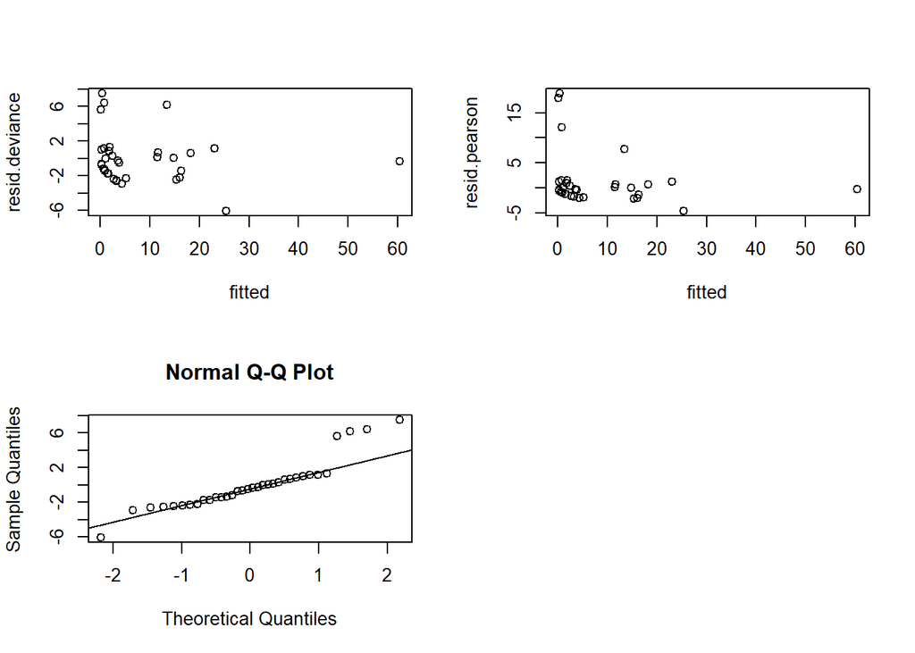

```r
# Plot the deviance residuals against the fitted values
par(mfrow=c(2,2))
#plot(fitted,ship_data$Damage_Incidents)
plot(fitted, resid.deviance)

# Plot the Pearson residuals against the fitted values
plot(fitted, resid.pearson)

# Create a Q-Q plot of the deviance residuals
qqnorm(resid.deviance)
qqline(resid.deviance)
```

```r
# goodness of fit test using the Chi-Square test:

with(summary(m.pois), pchisq(deviance, df = df.residual, lower.tail = FALSE))
```

```
## [1] 6.056898e-43
```

Upon performing a goodness-of-fit test we can see the p-value of the test, 6.056898e-43 which is virtually zero.So, there is very strong evidence that the model m.pois does not fit the data perfectly.

# Q# D

To address the given task, we will perform the following steps:

#Step 1: Load the Data into R First, we’ll create a data frame with the given table:

```r
# Create the data frame
homework_data <- data.frame(
  Homework_Cond = factor(rep(1:5, each = 3)),
  Teacher_Rating = factor(rep(c('A', 'B', 'C'), times = 5), ordered = TRUE),
  Frequency = c(141, 131, 36, 67, 66, 14, 114, 143, 38, 79, 72, 28, 39, 35, 16)
)

# View the data
print(homework_data)
```

```
##    Homework_Cond Teacher_Rating Frequency
## 1              1              A       141
## 2              1              B       131
## 3              1              C        36
## 4              2              A        67
## 5              2              B        66
## 6              2              C        14
## 7              3              A       114
## 8              3              B       143
## 9              3              C        38
## 10             4              A        79
## 11             4              B        72
## 12             4              C        28
## 13             5              A        39
## 14             5              B        35
## 15             5              C        16
```

#Step 2: Identify the Response Variable and its Distribution

The response variable is Teachers_Rating. Since it is an ordinal variable (A, B, C), we can use an ordinal regression model. One appropriate model is the proportional odds model, also known as the cumulative logit model.

#Step 3: Test Whether a Proportional Odds Model is an Appropriate Model

Proportional Odds Model Appropriateness: The proportional odds assumption was tested by fitting a cumulative link model with parallel lines (family = cumulative(parallel = TRUE)).

```r
# Test for proportional odds assumption
library(VGAM)
prop.mod <- vglm(Teacher_Rating ~ Homework_Cond, family = cumulative(parallel = TRUE), data = homework_data, weights = Frequency)
summary(prop.mod)
```

```
##
## Call:
## vglm(formula = Teacher_Rating ~ Homework_Cond, family = cumulative(parallel = TRUE),
##     data = homework_data, weights = Frequency)
##
## Coefficients:
##                Estimate Std. Error z value Pr(>|z|)
## (Intercept):1  -0.16797    0.11028  -1.523    0.128
## (Intercept):2   2.01734    0.13176  15.311   <2e-16 ***
## Homework_Cond2  0.03549    0.19129   0.186    0.853
## Homework_Cond3 -0.24556    0.15478  -1.587    0.113
## Homework_Cond4 -0.13371    0.17861  -0.749    0.454
## Homework_Cond5 -0.20586    0.22723  -0.906    0.365
## ---
## Signif. codes:  0 '***' 0.001 '**' 0.01 '*' 0.05 '.' 0.1 ' ' 1
##
## Names of linear predictors: logitlink(P[Y<=1]), logitlink(P[Y<=2])
##
## Residual deviance: 2011.567 on 24 degrees of freedom
##
## Log-likelihood: -1005.783 on 24 degrees of freedom
##
## Number of Fisher scoring iterations: 3
##
## No Hauck-Donner effect found in any of the estimates
##
##
## Exponentiated coefficients:
## Homework_Cond2 Homework_Cond3 Homework_Cond4 Homework_Cond5
##      1.0361245      0.7822669      0.8748453      0.8139480
```

```r
exp(coef(prop.mod))
```

```
##  (Intercept):1  (Intercept):2 Homework_Cond2 Homework_Cond3 Homework_Cond4
##      0.8453802      7.5182781      1.0361245      0.7822669      0.8748453
## Homework_Cond5
##      0.8139480
```

```r
# Get the coefficients from the model
coef <- coef(prop.mod)
coef
```

```
##  (Intercept):1  (Intercept):2 Homework_Cond2 Homework_Cond3 Homework_Cond4
##    -0.16796879     2.01733713     0.03548735    -0.24555934    -0.13370818
## Homework_Cond5
##    -0.20585885
```

```r
exp(confint(prop.mod, method='wald'))
```

```
##                    2.5 %   97.5 %
## (Intercept):1  0.6810575 1.049350
## (Intercept):2  5.8071760 9.733562
## Homework_Cond2 0.7121683 1.507444
## Homework_Cond3 0.5775712 1.059508
## Homework_Cond4 0.6164519 1.241548
## Homework_Cond5 0.5214051 1.270627
```

```r
# Calculate fitted values and getting the probability of getting a B
fitted_values <- fitted(prop.mod)
fitted_values
```

```
##            A         B         C
## 1  0.4581063 0.4244991 0.1173946
## 2  0.4581063 0.4244991 0.1173946
## 3  0.4581063 0.4244991 0.1173946
## 4  0.4669280 0.4193047 0.1137673
## 5  0.4669280 0.4193047 0.1137673
## 6  0.4669280 0.4193047 0.1137673
## 7  0.3980664 0.4566122 0.1453214
## 8  0.3980664 0.4566122 0.1453214
## 9  0.3980664 0.4566122 0.1453214
## 10 0.4251476 0.4428798 0.1319726
## 11 0.4251476 0.4428798 0.1319726
## 12 0.4251476 0.4428798 0.1319726
## 13 0.4076165 0.4519240 0.1404596
## 14 0.4076165 0.4519240 0.1404596
## 15 0.4076165 0.4519240 0.1404596
```

```r
# Calculate residuals
residuals <- residuals(prop.mod, type = "response")
residuals
```

```
##             A          B          C
## 1   0.5418937 -0.4244991 -0.1173946
## 2  -0.4581063  0.5755009 -0.1173946
## 3  -0.4581063 -0.4244991  0.8826054
## 4   0.5330720 -0.4193047 -0.1137673
## 5  -0.4669280  0.5806953 -0.1137673
## 6  -0.4669280 -0.4193047  0.8862327
## 7   0.6019336 -0.4566122 -0.1453214
## 8  -0.3980664  0.5433878 -0.1453214
## 9  -0.3980664 -0.4566122  0.8546786
## 10  0.5748524 -0.4428798 -0.1319726
## 11 -0.4251476  0.5571202 -0.1319726
## 12 -0.4251476 -0.4428798  0.8680274
## 13  0.5923835 -0.4519240 -0.1404596
## 14 -0.4076165  0.5480760 -0.1404596
## 15 -0.4076165 -0.4519240  0.8595404
```

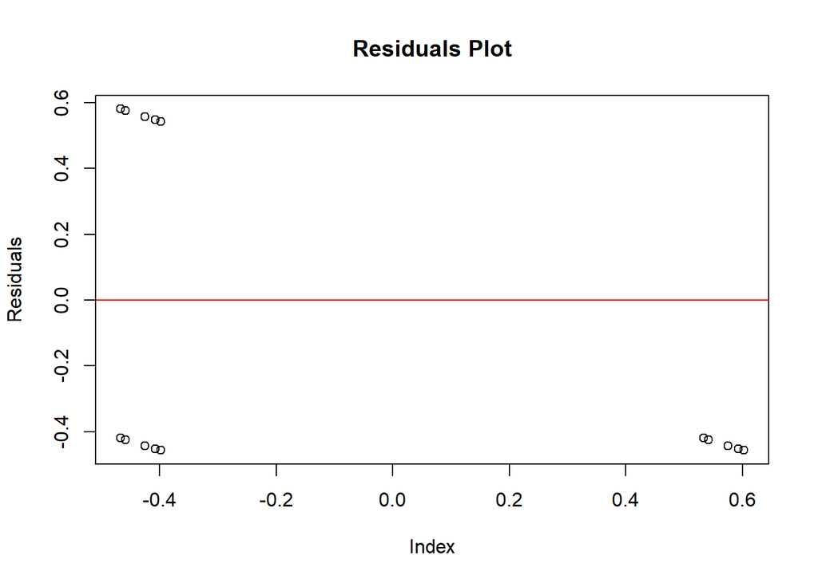

```r
# Plot residuals
plot(residuals, main = "Residuals Plot", xlab = "Index", ylab = "Residuals")
abline(h = 0, col = "red")
```

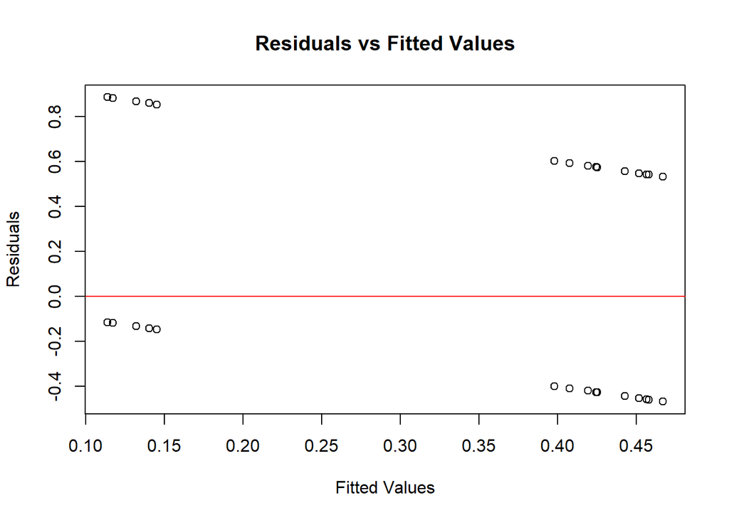

```r
# Create residuals vs fitted values plot
plot(fitted_values, residuals, main = "Residuals vs Fitted Values", xlab = "Fitted Values", ylab = "Residuals")
abline(h = 0, col = "red")
```

# Probability of B Rating:

The fitted probabilities for each category of Teacher_Rating are provided in the output. For instance, if we take row 2 , we see that category B has a fitted probability value of approximately 0.4244991 (42%).

```r
# Test for proportional odds assumption

# Fit a non-proportional odds model for comparison
noprop.mod <- vglm(Teacher_Rating ~ Homework_Cond, family = cumulative, data = homework_data, weights = Frequency)
summary(noprop.mod)
```

```
##
## Call:
## vglm(formula = Teacher_Rating ~ Homework_Cond, family = cumulative,
##     data = homework_data, weights = Frequency)
##
## Coefficients:
##                  Estimate Std. Error z value Pr(>|z|)
## (Intercept):1    -0.16923    0.11437  -1.480   0.1389
## (Intercept):2     2.02228    0.17735  11.403   <2e-16 ***
## Homework_Cond2:1 -0.00810    0.20126  -0.040   0.9679
## Homework_Cond2:2  0.22901    0.33220   0.689   0.4906
## Homework_Cond3:1 -0.29307    0.16546  -1.771   0.0765 .
## Homework_Cond3:2 -0.11079    0.24832  -0.446   0.6555
## Homework_Cond4:1 -0.06649    0.18905  -0.352   0.7251
## Homework_Cond4:2 -0.33721    0.27164  -1.241   0.2145
## Homework_Cond5:1 -0.09903    0.24151  -0.410   0.6818
## Homework_Cond5:2 -0.49081    0.32775  -1.497   0.1343
## ---
## Signif. codes:  0 '***' 0.001 '**' 0.01 '*' 0.05 '.' 0.1 ' ' 1
##
## Names of linear predictors: logitlink(P[Y<=1]), logitlink(P[Y<=2])
##
## Residual deviance: 2006.217 on 20 degrees of freedom
##
## Log-likelihood: -1003.109 on 20 degrees of freedom
##
## Number of Fisher scoring iterations: 3
##
## No Hauck-Donner effect found in any of the estimates
##
##
## Exponentiated coefficients:
## Homework_Cond2:1 Homework_Cond2:2 Homework_Cond3:1 Homework_Cond3:2
##        0.9919326        1.2573527        0.7459739        0.8951238
## Homework_Cond4:1 Homework_Cond4:2 Homework_Cond5:1 Homework_Cond5:2
##        0.9356738        0.7137605        0.9057155        0.6121322
```

Note the residual deviance for the larger model noprop.mod is 2006.217 with 20 degrees of freedom. And the residual deviance for the smaller model prop.mod is 2011.567 with 24 degrees of freedom. Thus the difference 5.35 has a chi-square distribution with 4 degree of freedom. we can calculate the p-value associated to the null hypothesis that the smaller model fits the data well as follows:

```r
# p-value
p_value <- 1-pchisq(deviance(prop.mod)-deviance(noprop.mod), df=df.residual(prop.mod)-df.residual(noprop.mod))
# Print the p-value
print(paste("P-value:", p_value))
```

```
## [1] "P-value: 0.253277869216334"
```

In this case, the p-value is 0.2532779, which is greater than 0.05. This means we do not reject the null hypothesis. In the context of model comparison, this suggests that there is no significant difference between the prop.mod and noprop.mod models.

Summary: The proportional odds model fits the data well, and there is no significant advantage to using a more complex non-proportional odds model. This means that the relationship between homework conditions and teacher ratings can be adequately modeled using the simpler proportional odds model.

# Q# E

To address the problem, we will first create the data frame in R, and then fit appropriate models to analyze the effect of cholesterol and blood pressure on heart disease. We’ll also check the adequacy of the models.

#Step 1: Create the Data Frame We need to represent the table in a suitable format for analysis.

```r
# Load necessary library
library(tidyverse)

# Define the data
# Define the vectors with correct lengths
Blood_Pressure <- factor(rep(c('< 117', '117-126', '127-136', '137-146', '147-156', '157-166', '167-186', '> 187'), each = 7, length.out = 57))
Serum_Cholesterol <- factor(rep(c('< 200', '200-209', '210-219', '220-244', '245-259', '260-284', '> 284'), times = 8, length.out = 57))
Heart_Disease <- c(2, 0, 0, 0, 0, 1, 0,
                   0, 2, 1, 8, 0, 5, 1,
                   2, 0, 2, 2, 0, 2, 4,
                   4, 1, 0, 0, 6, 3, 2,
                   4, 2, 0, 0, 3, 2, 4,
                   1, 1, 0, 0, 1, 0, 2,
                   4, 3, 0, 0, 0, 2, 2,
                   6, 0, 3, 1, 1, 1, 1,1)
Total <- c(
           53, 21, 15, 20, 14, 22, 11,
           66, 27, 25, 69, 24, 22, 19,
           59, 34, 21, 83, 33, 26, 28,
           65, 19, 26, 81, 23, 34, 23,
           37, 16, 6,  29, 19, 16, 16,
           13, 10, 11, 15, 11, 13, 12,
           21, 5,  11, 27, 5,  16, 14,
           5,  1,   6, 10, 7,   7,  7,7)
# Create the data frame
data <- data.frame(
  Blood_Pressure = Blood_Pressure,
  Serum_Cholesterol = Serum_Cholesterol,
  Heart_Disease = Heart_Disease,
  Total = Total
)
print(data)
```

```
##    Blood_Pressure Serum_Cholesterol Heart_Disease Total
## 1           < 117             < 200             2    53
## 2           < 117           200-209             0    21
## 3           < 117           210-219             0    15
## 4           < 117           220-244             0    20
## 5           < 117           245-259             0    14
## 6           < 117           260-284             1    22
## 7           < 117             > 284             0    11
## 8         117-126             < 200             0    66
## 9         117-126           200-209             2    27
## 10        117-126           210-219             1    25
## 11        117-126           220-244             8    69
## 12        117-126           245-259             0    24
## 13        117-126           260-284             5    22
## 14        117-126             > 284             1    19
```

[output cut: 43 more lines]

#step 2: Fit the Model for the Effect of Cholesterol on Heart Disease We’ll start by fitting a logistic regression model to describe the effect of cholesterol on heart disease:

```r
# Fit a logistic regression model with Cholesterol as the predictor
model_chol <- glm(cbind(Heart_Disease, Total) ~ Serum_Cholesterol, data = data, family = binomial)

# Summary of the model
summary(model_chol)
```

```
##
## Call:
## glm(formula = cbind(Heart_Disease, Total) ~ Serum_Cholesterol,
##     family = binomial, data = data)
##
## Coefficients:
##                          Estimate Std. Error z value Pr(>|z|)
## (Intercept)              -2.60884    0.21150 -12.335   <2e-16 ***
## Serum_Cholesterol> 284    0.51390    0.33901   1.516   0.1295
## Serum_Cholesterol200-209 -0.08428    0.40418  -0.209   0.8348
## Serum_Cholesterol210-219 -0.39519    0.46868  -0.843   0.3991
## Serum_Cholesterol220-244 -0.80440    0.37234  -2.160   0.0307 *
## Serum_Cholesterol245-259  0.09408    0.37815   0.249   0.8035
## Serum_Cholesterol260-284  0.33158    0.33711   0.984   0.3253
## ---
## Signif. codes:  0 '***' 0.001 '**' 0.01 '*' 0.05 '.' 0.1 ' ' 1
##
## (Dispersion parameter for binomial family taken to be 1)
##
##     Null deviance: 127.11  on 56  degrees of freedom
## Residual deviance: 112.52  on 50  degrees of freedom
## AIC: 219.73
##
## Number of Fisher Scoring iterations: 5
```

#Step 3: Fit the Model for the Effects of Cholesterol and Blood Pressure on Heart Disease

```r
# Fit a logistic regression model with Cholesterol as the predictor
model_chol_bp <- glm(cbind(Heart_Disease, Total) ~ Serum_Cholesterol + Blood_Pressure, data = data, family = binomial)

# Summary of the model
summary(model_chol_bp)
```

```
##
## Call:
## glm(formula = cbind(Heart_Disease, Total) ~ Serum_Cholesterol +
##     Blood_Pressure, family = binomial, data = data)
##
## Coefficients:
##                           Estimate Std. Error z value Pr(>|z|)
## (Intercept)              -3.671096   0.529758  -6.930 4.22e-12 ***
## Serum_Cholesterol> 284    0.391743   0.347538   1.127  0.25966
## Serum_Cholesterol200-209 -0.005549   0.409580  -0.014  0.98919
## Serum_Cholesterol210-219 -0.527038   0.478671  -1.101  0.27088
## Serum_Cholesterol220-244 -0.864264   0.376973  -2.293  0.02187 *
## Serum_Cholesterol245-259  0.006982   0.386307   0.018  0.98558
## Serum_Cholesterol260-284  0.260223   0.343889   0.757  0.44923
## Blood_Pressure> 187       2.582698   0.604455   4.273 1.93e-05 ***
## Blood_Pressure117-126     1.135636   0.567216   2.002  0.04527 *
## Blood_Pressure127-136     0.639228   0.588876   1.086  0.27770
## Blood_Pressure137-146     0.978660   0.570460   1.716  0.08624 .
## Blood_Pressure147-156     1.484176   0.577268   2.571  0.01014 *
## Blood_Pressure157-166     0.874441   0.688508   1.270  0.20407
## Blood_Pressure167-186     1.557543   0.601892   2.588  0.00966 **
## ---
## Signif. codes:  0 '***' 0.001 '**' 0.01 '*' 0.05 '.' 0.1 ' ' 1
##
## (Dispersion parameter for binomial family taken to be 1)
##
##     Null deviance: 127.115  on 56  degrees of freedom
## Residual deviance:  82.993  on 43  degrees of freedom
## AIC: 204.2
##
## Number of Fisher Scoring iterations: 5
```

The model predicts the probability of heart disease based on serum cholesterol levels and blood pressure.Blood_Pressure 117-126, Blood_Pressure 147-156, and Blood_Pressure 167-186 are statistically significant predictors at the 0.05 level.

#Check the adequacy of both models, Perform the ANOVA Test:

To compare the two models and determine if adding blood pressure significantly improves the fit.

```r
# Compare the models using ANOVA
anova(model_chol, model_chol_bp, test = "Chisq")
```

```
## Analysis of Deviance Table
##
## Model 1: cbind(Heart_Disease, Total) ~ Serum_Cholesterol
## Model 2: cbind(Heart_Disease, Total) ~ Serum_Cholesterol + Blood_Pressure
##   Resid. Df Resid. Dev Df Deviance  Pr(>Chi)
## 1        50    112.522
## 2        43     82.993  7   29.529 0.0001158 ***
## ---
## Signif. codes:  0 '***' 0.001 '**' 0.01 '*' 0.05 '.' 0.1 ' ' 1
```

#Interpretation

The deviance reduction (29.529) when adding Blood_Pressure to the model is highly significant (p-value = 0.0001158). This indicates that Blood_Pressure adds significant explanatory power to the model over and above Serum_Cholesterol alone.

#Significance:

The p-value (0.0001158) is much smaller than 0.05, indicating that the inclusion of Blood_Pressure significantly improves the model. The "***" next to the p-value indicates a high level of significance.

#Conclusion:

The results suggest that both Serum_Cholesterol and Blood_Pressure are important predictors of heart disease. Including Blood_Pressure significantly improves the model’s fit, indicating it has a significant effect on the likelihood of developing heart disease.

#Summary The analysis shows that the model with both Serum_Cholesterol and Blood_Pressure fits the data significantly better than the model with Serum_Cholesterol alone. This implies that Blood_Pressure is an important additional predictor of heart disease, and its inclusion improves the model’s explanatory power.

# Q#F

```r
#if (!requireNamespace("catdata", quietly = TRUE)) {
  #install.packages("catdata")}
library(catdata)

# Load the medcare dataset
data(medcare)
# View the first few rows of the dataset
head(medcare)
```

```
##   ofp hosp healthpoor healthexcellent numchron male age married school
## 1   5    1          0               0        2    1 6.9       1      6
## 2   1    0          0               0        2    0 7.4       1     10
## 3  13    3          1               0        4    0 6.6       0     10
## 4  16    1          1               0        2    1 7.6       1      3
## 5   3    0          0               0        2    0 7.9       1      6
## 6  17    0          1               0        5    0 6.6       0      7
```

```r
# Summarize the dataset
#summary(medcare)
```

#Identify the Response Variable Based on the problem statement, the number of physician/non-physician office and hospital outpatient visits (ofp) is a suitable response variable to represent the demand for medical care.

#Fit an Appropriate Predictive Regression Model Since ofp is a count variable, we can use a Poisson regression model. However, if there is overdispersion, we might need to switch to a Negative Binomial model.

```r
c(mean(medcare$ofp, na.rm=TRUE), var(medcare$ofp, na.rm=TRUE))
```

```
## [1]  5.774399 45.687117
```

- There is evidence of over-dispersion since variance of `ofp` is much higher than the mean of `ofp`.
- A negative binomial regression model is an appropriate model for a count response in the presence of over-dispersion.

```r
# Fit a Poisson regression model
poisson_model <- glm(ofp ~ hosp + numchron + age + married + school, family = poisson, data = medcare)

# Summarize the model
summary(poisson_model)
```

```
##
## Call:
## glm(formula = ofp ~ hosp + numchron + age + married + school,
##     family = poisson, data = medcare)
##
## Coefficients:
##              Estimate Std. Error z value Pr(>|z|)
## (Intercept)  1.437409   0.082331  17.459  < 2e-16 ***
## hosp         0.184073   0.005883  31.287  < 2e-16 ***
## numchron     0.173106   0.004258  40.654  < 2e-16 ***
## age         -0.042016   0.010377  -4.049 5.14e-05 ***
## married     -0.068096   0.013061  -5.214 1.85e-07 ***
## school       0.027976   0.001746  16.023  < 2e-16 ***
## ---
## Signif. codes:  0 '***' 0.001 '**' 0.01 '*' 0.05 '.' 0.1 ' ' 1
##
## (Dispersion parameter for poisson family taken to be 1)
##
##     Null deviance: 26943  on 4405  degrees of freedom
## Residual deviance: 23686  on 4400  degrees of freedom
## AIC: 36474
##
## Number of Fisher Scoring iterations: 5
```

Interpretation of the results: The coefficients represent the change in the log of expected counts of ofp for a one-unit increase in the predictor variable, assuming all other variables are held constant. hosp: For each additional hospital stay, the expected log count of ofp increases by 0.184. numchron: For each additional chronic condition, the expected log count of ofp increases by 0.173. age: For each additional year of age, the expected log count of ofp decreases by 0.042. married: If the individual is married, the expected log count of ofp decreases by 0.068 compared to non-married individuals. school: For each additional year of education, the expected log count of ofp increases by 0.028.

```r
library(MASS)
medcare_nb <-glm.nb(ofp ~., data = medcare)
medcare_nb2 <-glm.nb(ofp ~ hosp+numchron+age+married+school, data = medcare)
```

```r
summary(medcare_nb)
```

```
##
## Call:
## glm.nb(formula = ofp ~ ., data = medcare, init.theta = 1.196371041,
##     link = log)
##
## Coefficients:
##                  Estimate Std. Error z value Pr(>|z|)
## (Intercept)      1.257212   0.200532   6.269 3.63e-10 ***
## hosp             0.224674   0.020258  11.090  < 2e-16 ***
## healthpoor       0.275830   0.048543   5.682 1.33e-08 ***
## healthexcellent -0.341813   0.061073  -5.597 2.18e-08 ***
## numchron         0.173753   0.012148  14.304  < 2e-16 ***
## male            -0.106616   0.034019  -3.134  0.00172 **
## age             -0.029204   0.025293  -1.155  0.24825
## married         -0.030506   0.034701  -0.879  0.37934
## school           0.034392   0.004248   8.096 5.66e-16 ***
## ---
## Signif. codes:  0 '***' 0.001 '**' 0.01 '*' 0.05 '.' 0.1 ' ' 1
##
## (Dispersion parameter for Negative Binomial(1.1964) family taken to be 1)
##
##     Null deviance: 5711.0  on 4405  degrees of freedom
## Residual deviance: 5045.7  on 4397  degrees of freedom
## AIC: 24390
##
## Number of Fisher Scoring iterations: 1
##
##
##               Theta:  1.1964
##           Std. Err.:  0.0332
##
##  2 x log-likelihood:  -24370.2520
```

We can see that all predictors except for age and married are significant. hosp: For each additional hospital stay, the expected log count of ofp increases by 0.225. healthpoor: For individuals with poor health, the expected log count of ofp increases by 0.276 compared to those with average health. healthexcellent: For individuals with excellent health, the expected log count of ofp decreases by 0.342 compared to those with average health. numchron: For each additional chronic condition, the expected log count of ofp increases by 0.174. school: For each additional year of education, the expected log count of ofp increases by 0.034.

```r
summary(medcare_nb2)
```

```
##
## Call:
## glm.nb(formula = ofp ~ hosp + numchron + age + married + school,
##     data = medcare, init.theta = 1.168508495, link = log)
##
## Coefficients:
##              Estimate Std. Error z value Pr(>|z|)
## (Intercept)  1.278097   0.201962   6.328 2.48e-10 ***
## hosp         0.242534   0.020263  11.969  < 2e-16 ***
## numchron     0.201075   0.011599  17.336  < 2e-16 ***
## age         -0.029971   0.025451  -1.178   0.2390
## married     -0.078690   0.032205  -2.443   0.0145 *
## school       0.028378   0.004223   6.719 1.83e-11 ***
## ---
## Signif. codes:  0 '***' 0.001 '**' 0.01 '*' 0.05 '.' 0.1 ' ' 1
##
## (Dispersion parameter for Negative Binomial(1.1685) family taken to be 1)
##
##     Null deviance: 5621.2  on 4405  degrees of freedom
## Residual deviance: 5046.7  on 4400  degrees of freedom
## AIC: 24463
##
## Number of Fisher Scoring iterations: 1
##
##
##               Theta:  1.1685
##           Std. Err.:  0.0322
##
##  2 x log-likelihood:  -24449.1390
```

```r
exp(coef(medcare_nb2))
```

```
## (Intercept)        hosp    numchron         age     married      school
##   3.5898035   1.2744740   1.2227163   0.9704738   0.9243262   1.0287843
```

```r
exp(confint(medcare_nb2))
```

```
##                 2.5 %    97.5 %
## (Intercept) 2.3891176 5.3891056
## hosp        1.2213240 1.3315170
## numchron    1.1939777 1.2523874
## age         0.9221111 1.0215922
## married     0.8678628 0.9843788
## school      1.0204043 1.0372218
```

From the test we can interpret that, age has almost no effect on this data, since the confidence intervsl overlaps 1.

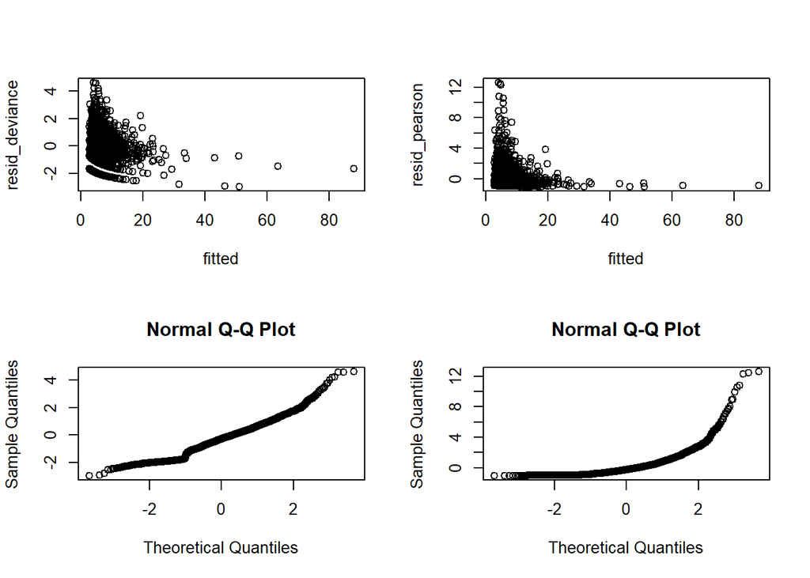

```r
#goodness of fit
fitted <- c(fitted.values(medcare_nb2))
resid_deviance = residuals(medcare_nb2,type="deviance")
resid_pearson = residuals(medcare_nb2,type="pearson")
par(mfrow=c(2,2))
plot(fitted,resid_deviance)
plot(fitted,resid_pearson)
qqnorm(resid_deviance)
qqnorm(resid_pearson)
```

The QQplots compare the quantiles of the standardized deviance residuals to the quantiles of a standard normal distribution.

The second QQplot shows some deviations from the line at both ends, suggesting some deviation from normality in the tails of the residuals.

# Q# G

load the data:

```r
library(catdata)

# Load the addiction dataset
data(addiction)
head(addiction)
```

```
##   ill gender age university
## 1   1      1  61          0
## 2   0      1  43          0
## 3   2      0  44          0
## 4   0      1  21          1
## 5   0      0  33          0
## 6   1      0  83          0
```

```r
#load appropriate library
library(VGAM)

addiction_mod_fit <- vglm(ill ~ gender+age+university, family = multinomial, data = addiction)
summary(addiction_mod_fit)
```

```
##
## Call:
## vglm(formula = ill ~ gender + age + university, family = multinomial,
##     data = addiction)
##
## Coefficients:
##                Estimate Std. Error z value Pr(>|z|)
## (Intercept):1  2.015564   0.307627   6.552 5.68e-11 ***
## (Intercept):2  0.854850   0.286286   2.986 0.002827 **
## gender:1      -0.287912   0.220779  -1.304 0.192209
## gender:2       0.148695   0.196729   0.756 0.449745
## age:1         -0.042086   0.006821  -6.170 6.83e-10 ***
## age:2         -0.012176   0.005574  -2.184 0.028945 *
## university:1  -1.067287   0.289110  -3.692 0.000223 ***
## university:2   0.554761   0.214141   2.591 0.009580 **
## ---
## Signif. codes:  0 '***' 0.001 '**' 0.01 '*' 0.05 '.' 0.1 ' ' 1
##
## Names of linear predictors: log(mu[,1]/mu[,3]), log(mu[,2]/mu[,3])
##
## Residual deviance: 1350.417 on 1356 degrees of freedom
##
## Log-likelihood: -675.2085 on 1356 degrees of freedom
##
## Number of Fisher scoring iterations: 4
##
## No Hauck-Donner effect found in any of the estimates
##
##
## Reference group is level  3  of the response
```

In this analysis, we have fitted a multinomial logistic regression model to investigate how the response to the question “Is addiction a disease or are addicts weak-willed?” depends on gender, age, and education level. The response variable has three categories: “addicts are weak-willed,” “addiction is a disease,” and “both alternatives hold.” The reference category for the response variable is “both alternatives hold.”

Summary of Findings Age: Both log-odds of responding “addicts are weak-willed” and “addiction is a disease” relative to “both alternatives hold” decrease with age, indicating older individuals are less likely to view addiction in binary terms of either weak-willed or a disease. The p-values for both age1 and age2 are less than 0.05, indicating that the effect of age on illness is statistically significant.The coefficients for age1 and age2 are both negative, indicating that as age increases, the log odds of being ill decrease

University Education: Having a university education significantly decreases the log-odds of viewing addiction as a result of weak willpower and increases the log-odds of viewing it as a disease. This suggests that higher education is linked with a better understanding of addiction. The negative coefficient for university1 suggests that university = 0 is associated with lower odds of being ill, while the positive coefficient for university:2 suggests that university = 1 is associated with higher odds of being ill. Both effects are statistically significant (p < 0.05).

Gender: Gender does not significantly affect the odds of choosing either response compared to the reference category, indicating that men and women have similar views on this issue. The p-values for both gender1 and gender2 are greater than 0.05, suggesting that the effect of gender on illness is not statistically significant in this model.

Model Goodness-of-Fit Residual Deviance: 1350.417 on 1356 degrees of freedom. A lower residual deviance indicates a better fit, but this value should be compared against a null model for context. Log-Likelihood: -675.2085 on 1356 degrees of freedom. This value is used for comparison with other models; higher (less negative) log-likelihood indicates a better fit.

```r
# Display the coefficients
coefficients(addiction_mod_fit)
```

```
## (Intercept):1 (Intercept):2      gender:1      gender:2         age:1
##    2.01556413    0.85484995   -0.28791193    0.14869539   -0.04208644
##         age:2  university:1  university:2
##   -0.01217555   -1.06728719    0.55476125
```

```r
# Calculate the odds ratios for better interpretation
exp(coefficients(addiction_mod_fit))
```

```
## (Intercept):1 (Intercept):2      gender:1      gender:2         age:1
##     7.5049600     2.3510216     0.7498276     1.1603195     0.9587869
##         age:2  university:1  university:2
##     0.9878983     0.3439403     1.7415252
```

Summary of Findings Intercepts:

Gender:

Age:

University Education:

Having a university education significantly decreases the log-odds of viewing addiction as a result of weak willpower and increases the log-odds of viewing it as a disease. This suggests that higher education is associated with a more nuanced understanding of addiction. Conclusion

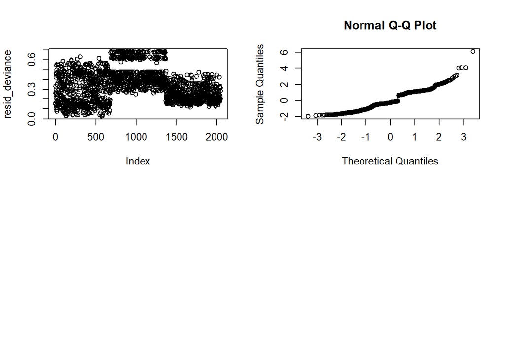

```r
#goodness of fit
fitted <- c(fitted.values(addiction_mod_fit))
resid_deviance = residuals(addiction_mod_fit,type="deviance")
resid_pearson = residuals(addiction_mod_fit,type="pearson")
par(mfrow=c(2,2))
plot(fitted,resid_deviance)
qqnorm(resid_pearson)
```